# 03 home work

ShinichiOtoshi

Wednesday, October 21, 2014

#### HTMLファイル作成情報

```
## HTML作成日: 2014-10-21 07:50:31
```

```
## OS: windows
```

## 問題1 階乗を計算する関数を作る。

### (1) 関数の作成

非負の整数$n$の階乗（ただし、$n$は非負の整数）を計算する関数を作成する。非負の整数の階乗は次式のように表す。 $n!=n(n-1)(n-2)\cdots1$ $0!=1$ 次のスクリプトでは、引数として与えられた数値について判断し、計算を行うようにしている。具体的には、負の値が代入された場合、`NULL`を返し、0が代入された場合は`1`を返すようにする。$n$が非負の0ではない数字であった場合は、変数xに変数nの値を代入し、$(n-1)$をかける。そして、次のループへ$(n-1)$した数を渡す。これをwhileループで$n=1$となるまで回している。

```r
f.fctrl <- function(n = NULL){
    ## 引　数: n = 階乗する数（数値：非負の整数）
    ## 返り値: x = 階乗した数（数値）
    if(n < 0){           # nが0のとき
        return(NULL)

    } else if (n == 0){  # nが負の時
        return(1)

    } else if (n > 0){  # nが正の時
        x <- n               # nにループの中で初めの値として保つためにxに代入
        while(n > 1){
            x <- x * (n - 1) # 引数として与えられた数nを(n-1)でかける
            n <- n - 1       # 次のループに(n-1)した数を渡す
        }
        return(x)
    }
}
```

### (2) 試しに出力

試験的に出力する。ここでは仮の値として、$5!$を計算する。

```r
# 試しに5を代入
5 * 4 * 3 * 2 * 1

# 関数テスト
f.fctrl(5)
```

```
## [1] 120
```

```
## [1] 120
```

## 問題2 自分が作成した階乗の関数を用いて、組み合わせを計算する関数を作る。

ここでは、組み合わせの数を計算する関数を作成する。$n$個から$k$個選ぶ組み合わせは次式のようになる。 ${n \choose k}=\frac{n!}{k!(n-k)!}$ 先ほど作成した階乗の関数`f.fctrl`を利用して、組み合わせの数を計算する関数を作成する。

### (1) 関数の作成

```r
f.chse <- function(n = NULL, k = NULL){
    ## 引　数: n = から（数値）
    ## 　　　: k = 選ぶ（数値）
    ## 返り値: output = 組み合わせ計算結果（数値）

    output <- f.fctrl(n) / (f.fctrl(k) * f.fctrl(n - k))  # 上記の公式から
    return(output)
}
```

### (2) 試しに出力

試しに出力する。ここでは仮の値として、4個から2個選ぶ場合を想定する。

```r
# 試しにn=4、k=2を代入
4*3*2*1/((2*1)*(2*1))

# 関数テスト
f.chse(n = 4, k = 2)
```

```
## [1] 6
```

```
## [1] 6
```

## 問題3 自分が作成した組み合わせの関数を用いて、二項分布の確率質量を求める関数を作る。

### (1) 関数の作成

二項分布の確率質量関数 $f(x)$ は $f(x)={n \choose x}p^x(1-p)^{n-x}\;\;\;\;\;(x=0,1,2,3\cdots n)$ である。ここで$n$はベルヌーイ試行の回数、$p$は１回のベルヌーイ試行における成功確率である。$x$は$0$～$n$までの整数の値をとる。次降のスクリプトでは、`x`にパラメータ、`size`に試行回数、`prob`に成功確率を引数として、二項分布の質量関数を計算する関数`den_bin`を作成する。返り値はベクトルで返される。

```r
den_bin <- function(x = NULL, size = NULL, prob = NULL){
    ## 引　数: x = パラメータ（数値・ベクトル）
    ## 　　　  size = 試行回数（数値）
    ## 　　　  prob = 成功確率（数値）
    ## 返り値: output = 確率質量関数（数値・ベクトル）

    # 結果を保存するベクトルを用意
    output <- rep(NA, length(x))

        for(i in 1:length(x)){
        # 公式を元にi番目のベクトルに計算結果を代入
        output[i] <- f.chse(n = size, k = x[i]) * (prob^x[i]) * (1 - prob)^(size - x[i])
    }
    return(output)
}
```

### (2) 試しに出力

試しに出力してみる。ここでは、$x$が0～10までの値を取り、成功確率は、0.3とする。つまり、試行回数（`size`）は10回、成功確率（`prob`）は0.3とする。

```r
den_bin(x = 0:10, size = 10, prob = 0.3)
```

```
##  [1] 2.825e-02 1.211e-01 2.335e-01 2.668e-01 2.001e-01 1.029e-01 3.676e-02
##  [8] 9.002e-03 1.447e-03 1.378e-04 5.905e-06
```

## 問題4 自分が作成した二項分布の関数を用いて、$n$が2, 3, 4, 5, 10の場合について2つ以上の$p$で図示する。

### (1) 異なる$p$について計算する関数を作成する。

まず、複数の確率についてシミュレーションを行う関数を作成する。この関数では引数として与えられた複数の確率`p.vec`を元に、ある$n$におけるそれぞれの成功確率$p$での確率質量を計算する。具体的には与えられた引数$n$を元に$0$～$n$まで$x$が変化するとき、異なる$p$での確率質量を求める関数である。返り値は行列で返され、最初の列には、二項係数${n \choose x}$の$0$～$n$の数を代入している。

```r
sim.denbin <- function(n = NULL, p.vec = NULL){
    ## 引　数: n = nのベクトル（0～nまでシミュする）
    ## 　　　: p.vec = 成功確率（ベクトルとして複数与える）
    ## 返り値: output = 確率質量関数の行列（最後列は代入されたkの数）

    # 結果を保存する行列を用意
    output <- matrix(data = NA, nrow = length(0:n), ncol = (length(p.vec)) + 1)

    # 最初の列にx～nの値を代入
    output[, 1] <- c(0:n)

    for(i in 1:length(p.vec)){
        # 関数を利用してoutputのi+1番目の列を計算する
        output[,i+1] <- den_bin(x = c(0:n), size = n, prob = p.vec[i])
    }
    return(output)
}
```

### (2) 確率質量関数を図示する。

`for`を使い、異なる$p$と$n$について計算・図示を行う。$n$は$2, 3, 5, 10$とし、各$n$に対する$p$は$0.2, 0.5, 0.8$とする。関数`sim.denbin`は、ある$n$における異なる$p$での確率質量関数を返すので、ここでは$n$をベクトル`n_array`に保存して、計算と図示を行う。

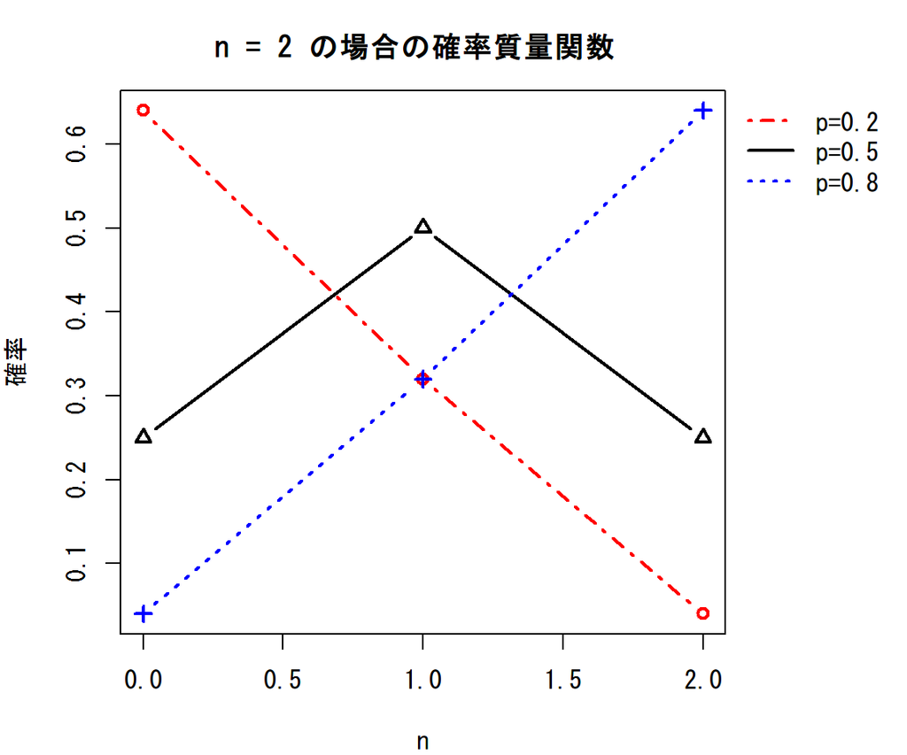

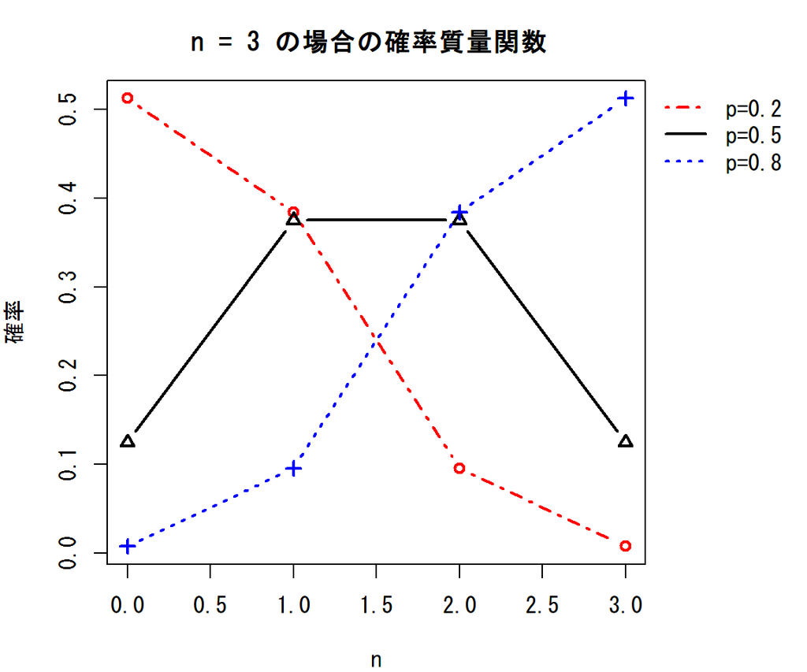

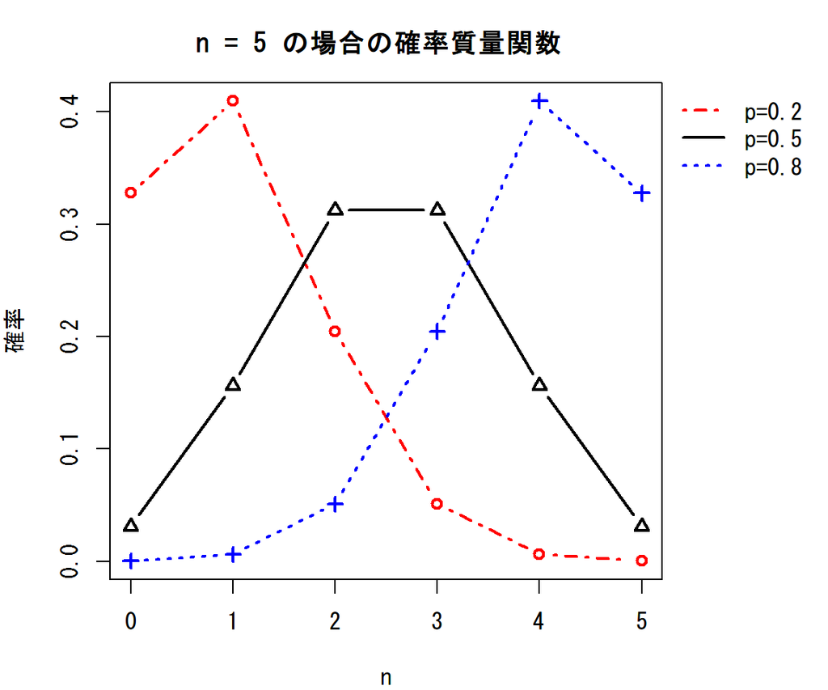

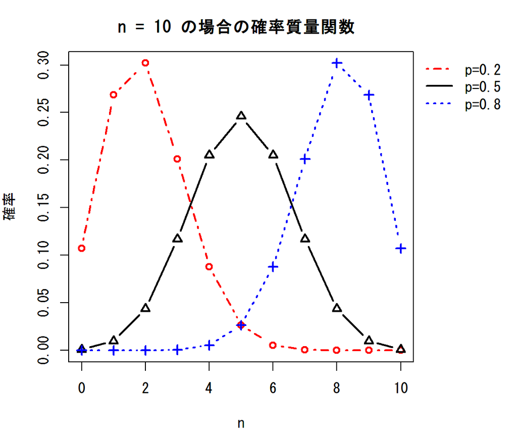

```r
# nのベクトル（４つ）
n_array <- c(2, 3, 5, 10)

# pのベクトル（３つ）
p_array <- c(0.2, 0.5, 0.8)

for(i in n_array){
    # 0:i（0:n）までの確率p.vecの確率質量関数を行列で出す
    sim.res <- sim.denbin(n = i, p.vec = p_array)

    # 凡例を加える余白を右に作成
    par(mar = c(4, 4, 3, 6))

    # matplot関数を利用して、作図
    matplot(x = sim.res[, 1], y = sim.res[, 2:4],
            type = "b", lwd = 2,
            xlab = "n", ylab = "確率",
            main = paste("n =", i, "の場合の確率質量関数", seq = ""),
            lty = c("dotdash", "solid", "dotted"),
            col = c("red", "black", "blue"),
            pch = c(1, 2, 3)
            )


    # 枠の外への描画を許可
    par(xpd=T)

    # 凡例を追加
    legend(par()$usr[2], par()$usr[4],
           legend = c("p=0.2","p=0.5", "p=0.8"), bty = "n",
           lty = c("dotdash", "solid", "dotted"),
           col = c("red", "black", "blue"),
           lwd = 2)
}
```

## 課題内容・参考文献・参考URL

- 矢内勇生. 「課題03」. アクセス 2014年10月18日. URL:[http://www2.kobe-u.ac.jp/~yyanai/jp/classes/rm1/contents/docs/rm1_assignment03.pdf]
- ――――. 「政治学方法論 I：Rマークダウンの例」. アクセス 2014年10月18日. URL:[http://www2.kobe-u.ac.jp/~yyanai/jp/classes/rm1/contents/R/example-Markdown.html]
- 飯田健. 2013. 計量政治分析. Rで学ぶデータサイエンス 14. 共立出版